fossil

# The Diabetes Classifier, dug back up.

Neither the web tool nor its code survived. We rebuilt the cohort from the NHANES 1999 to 2004 files and the method from the text. Diagnosed diabetes comes back at 1,266 people (paper 1,266). Over 10 random splits the SVM’s median test AUC is 0.825 for diabetes and 0.732 for pre-diabetes or undiagnosed diabetes (paper 0.8347 and 0.7318), and it ties with logistic regression, as the paper says.

See the tables

## Install diabclass

Python package

```
pip install "git+https://github.com/jeonglab-bcm/fossil#subdirectory=PMC2850872/package"
```

Python 3.10 or later, with NumPy, SciPy, scikit-learn and joblib.

[README](https://github.com/jeonglab-bcm/fossil/blob/main/PMC2850872/package/README.md) [Tutorial](https://github.com/jeonglab-bcm/fossil/blob/main/PMC2850872/package/tutorial/TUTORIAL.md)

## Fig. 2

ROC curves of the SVM (black) and the logistic regression (grey) on the test set, for scheme I (a: diabetes against everyone else) and scheme II (b: undiagnosed diabetes or pre-diabetes against no diabetes).

Agreespanel a, 14 of 17 values, on reviewAgreespanel b, 16 of 18 values, on review

Published

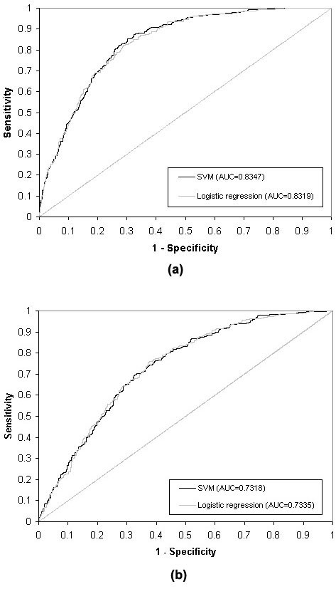

Our split 0

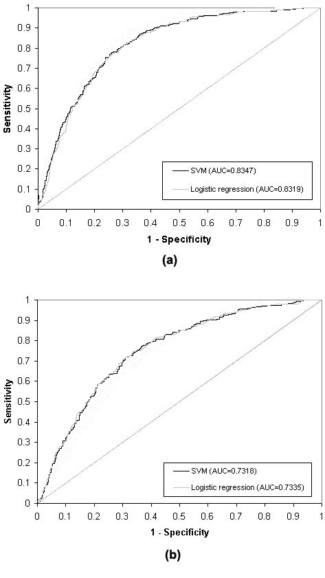

**Pixel size**

473 × 841

**Tolerance**

2 px

**Panel a, ours**

28%

**Panel a, best control**

32% (sensitivity +0.03)

**Panel b, ours**

21%

**Panel b, best control**

14% (scheme I curve)

**Tick fit residual**

0.45 px

Our curves are from split 0. The paper’s split was never published, and the curves of two random splits differ by about as much as a curve moved 0.03 in sensitivity, so a pixel score cannot single out the paper’s split. In data units, the published sensitivity at nine false-positive rates lies within two standard deviations of our median for 14 of 17 values in panel a and 16 of 18 values in panel b.

## Tables 1 to 3

Table 1: people per diabetes category, NHANES 1999 to 2004, adults aged 20 or over, not pregnant. Tables 2 and 3: published value / our median over 10 random 80/20 splits (our range).

Agrees1 of 8 values, on reviewAgrees6 of 8 values, on review

Table 1 (paper; ours; difference)

| Category | Paper | Ours | Δ |
| --- | --- | --- | --- |
| Diagnosed diabetes | 1,266 | **1,266** | +0 |
| Undiagnosed diabetes | 195 | **196** | +1 |
| Pre-diabetes | 1,576 | **1,571** | -5 |
| No diabetes | 3,277 | **3,272** | -5 |
| Scheme I cases | 1,461 | **1,462** | +1 |
| Scheme I non-cases | 4,853 | **4,843** | -10 |
| Scheme II cases | 1,709 | **1,717** | +8 |
| Scheme II non-cases | 3,206 | **3,210** | +4 |

Diagnosed diabetes comes back exactly. The fasting groups come back within a handful of people, with glucose counted for people who fasted at least 8 hours, “borderline” answers counted as not diagnosed and “don’t know” as no. The paper does not name its physical activity variable; moderate activity in the past 30 days (PAD320) leaves the scheme II totals closest to the paper’s.

Table 2. Test AUC per kernel (paper / ours)

| Scheme | Linear | Polynomial | RBF | Sigmoid |
| --- | --- | --- | --- | --- |
| Scheme I | 0.8332 / **0.8244** 0.814 to 0.850 | 0.7655 / **0.8175** 0.802 to 0.829 | 0.8347 / **0.8253** 0.815 to 0.839 | 0.8341 / **0.8232** 0.813 to 0.850 |
| Scheme II | 0.7318 / **0.7317** 0.708 to 0.760 | 0.6673 / **0.7158** 0.677 to 0.725 | 0.7259 / **0.7299** 0.707 to 0.759 | 0.7273 / **0.7314** 0.708 to 0.761 |

Table 3. Best kernel per scheme (paper / ours)

| Row | Sensitivity | Specificity | PPV | NPV | AUC |
| --- | --- | --- | --- | --- | --- |
| Scheme I (RBF), Test | 0.7715 / **0.7928** 0.740 to 0.808 | 0.7503 / **0.7128** 0.685 to 0.759 | 0.4926 / **0.4522** 0.435 to 0.481 | 0.9127 / **0.9196** 0.906 to 0.926 | 0.8347 / **0.8253** 0.815 to 0.839 |
| Scheme I (RBF), Training | 0.7938 / **0.8030** 0.789 to 0.816 | 0.7169 / **0.7218** 0.705 to 0.748 | 0.4550 / **0.4669** 0.455 to 0.486 | 0.9211 / **0.9238** 0.920 to 0.927 | 0.8383 / **0.8387** 0.835 to 0.842 |
| Scheme I (RBF), 10-fold CV | 0.7765 / **0.8027** 0.794 to 0.815 | 0.7027 / **0.7178** 0.701 to 0.726 | 0.4388 / **0.4621** 0.452 to 0.467 | 0.9130 / **0.9233** 0.921 to 0.926 | 0.8242 / **0.8347** 0.825 to 0.837 |
| Scheme II (linear), Test | 0.7359 / **0.7085** 0.665 to 0.732 | 0.6254 / **0.6550** 0.623 to 0.687 | 0.5061 / **0.5179** 0.506 to 0.555 | 0.8195 / **0.8048** 0.785 to 0.827 | 0.7318 / **0.7317** 0.708 to 0.760 |
| Scheme II (linear), Training | 0.7092 / **0.7114** 0.705 to 0.724 | 0.6590 / **0.6543** 0.631 to 0.670 | 0.6729 / **0.6734** 0.660 to 0.682 | 0.8087 / **0.6932** 0.685 to 0.702 | 0.7393 / **0.7390** 0.725 to 0.749 |
| Scheme II (linear), 10-fold CV | 0.7059 / **0.7069** 0.698 to 0.720 | 0.6589 / **0.6538** 0.645 to 0.660 | 0.5293 / **0.5233** 0.516 to 0.527 | 0.8054 / **0.8064** 0.803 to 0.813 | 0.7357 / **0.7339** 0.726 to 0.739 |

Agrees9 of 15 values, on review Agrees14 of 14 values A value agrees when the paper’s lies within two standard deviations of our median, the range one random split lands in about 95% of the time. The paper’s training row is the whole training set for scheme I and the balanced sample for scheme II: that is the prevalence each row’s PPV implies. The scheme II training NPV implies the whole training set instead, so no one set gives that row; it is left out of the count.

## Claims in the text

Our median over 10 splits against the paper’s numbers. The logistic regression is weighted by the NHANES examination weights and fitted to the whole training set.

Agrees4 of 4 values

Claims (paper; ours; agrees)

| Claim | Paper | Ours | Agrees |
| --- | --- | --- | --- |
| Scheme I, logistic regression AUC | 0.8319 | **0.8263** | yes |
| Scheme II, logistic regression AUC | 0.7335 | **0.7340** | yes |
| Scheme I, DeLong P | 0.3672 | **0.4676** | yes |
| Scheme I, SVM and logistic AUCs differ at P < 0.05 | no | **no** | yes |
| Scheme II, DeLong P | 0.6718 | **0.3468** | yes |
| Scheme II, SVM and logistic AUCs differ at P < 0.05 | no | **no** | yes |
| Scheme I, best kernel by test AUC | RBF | **RBF** | yes |
| Scheme II, best kernel by test AUC | linear | **linear** | yes |
| Scheme I, worst kernel (polynomial) | polynomial | **polynomial** | yes |
| Scheme II, worst kernel (polynomial) | polynomial | **polynomial** | yes |

The paper’s own numbers: 14 of 15 arithmetic checks on Tables 1 and 3 hold. Our code against R: On split 0: logistic coefficients equal to survey::svyglm within 1e-10; DeLong P equal to pROC::roc.test within 1e-06; SVM test AUC from e1071 (LIBSVM in R) with the same C and gamma 0.8187 against 0.8187, 0.7481 against 0.7481.

**The main claim holds: on both schemes the SVM discriminates as well as the logistic regression, and the DeLong test finds no difference in 8 and 8 of 10 splits. The polynomial kernels come back better than published, as an untuned model would explain; the scheme I 10-fold CV and test PPV stay apart, cause open.**

## What came back

**The cohort**

All 33 NHANES files still download from the CDC. Diagnosed diabetes at 1,266 people; the scheme I totals at 1,462 cases and 4,843 non-cases (paper 1,461 and 4,853).

**The method**

LIBSVM with grid.py’s default grid, trained on all cases and as many random non-cases. It is now a Python package, diabclass, with a tutorial: [PMC2850872/package](https://github.com/jeonglab-bcm/fossil/blob/main/PMC2850872/package/tutorial/TUTORIAL.md).

**The comparison**

A survey-weighted logistic regression and the DeLong test, checked against R’s survey and pROC packages.

**The tie**

On scheme I the SVM and the logistic regression differ by -0.0000 in median AUC; on scheme II by -0.0018. DeLong P is below 0.05 in 2 and 2 of 10 splits.

## What stayed buried

- The Diabetes Classifier web tool and its Java code
- The paper’s random 80/20 split and its undersampled training set
- Which NHANES items stand for family history, hypertension and physical activity, and the divisors for weight, height, waist and BMI
- The polynomial kernel’s degree and offset, and the survey weight given to SUDAAN

The main claim holds: on both schemes the SVM discriminates as well as the logistic regression, and the DeLong test finds no difference in 8 and 8 of 10 splits. The polynomial kernels come back better than published, as an untuned model would explain; the scheme I 10-fold CV and test PPV stay apart, cause open.

## What we matched

Figure 2 is an Excel chart. We draw our ROC curves on the published pixel grid: each axis is mapped from its eleven tick marks, so a curve lands where the paper’s would. The SVM curve is black and the logistic regression curve grey, as in the paper.

**Our run**

10 random splits per scheme. Each: 80% of every Table 1 category to training, a balanced sample, grid.py’s search per kernel (5-fold CV), the test AUC, Table 3’s rows, the weighted logistic regression and the DeLong test.

**Axes**

One linear map per axis from the eleven tick marks of each panel.

**Scores**

Share of the published trace within 2 px of ours and of ours within 2 px of the published, the smaller of the two. Legend and diagonal masked.

**Controls**

The other scheme’s curve and age alone (wrong inputs), and our curve with sensitivity moved by 0.03 either way (near misses).

**Reading the views**

Overlay: ink is the paper only, light green is the reproduction only, dark green is both.

## The session

Session not recorded: no log of the agent session was kept for this reproduction.